# This is a report as part of the reproducible research report

## Loading and preprocessing the data

### 1. Load the data (i.e. read.csv())

```r
#load the data
if(!file.exists('activity.csv')){
        unzip('activity.zip')
}
activityData <- read.csv('activity.csv', stringsAsFactors=FALSE)
```

### 2. Process/transform the data (if necessary) into a format suitable for analysis

```r
#change date to actual date format
activityData$date <- as.POSIXct(activityData$date, format="%Y-%m-%d")

#isolate the weekdays
activityData <- data.frame(date=activityData$date,
                           weekday=tolower(weekdays(activityData$date)),
                           steps=activityData$steps,
                           interval=activityData$interval)

#check if it is weekend or weekday
activityData <- cbind(activityData,
                      daytype=ifelse(activityData$weekday == "saturday" |
                      activityData$weekday == "sunday", "weekend", "weekday"))

#create the data format
activityNew <- data.frame(date=activityData$date,
                       weekday=activityData$weekday,
                       daytype=activityData$daytype,
                       interval=activityData$interval,
                       steps=activityData$steps)
```

### study the header and structure of data

```r
head(activityNew)
```

```
##         date weekday daytype interval steps
## 1 2012-10-01  monday weekday        0    NA
## 2 2012-10-01  monday weekday        5    NA
## 3 2012-10-01  monday weekday       10    NA
## 4 2012-10-01  monday weekday       15    NA
## 5 2012-10-01  monday weekday       20    NA
## 6 2012-10-01  monday weekday       25    NA
```

```r
str(activityNew)
```

```
## 'data.frame':    17568 obs. of  5 variables:
##  $ date    : POSIXct, format: "2012-10-01" "2012-10-01" ...
##  $ weekday : Factor w/ 7 levels "friday","monday",..: 2 2 2 2 2 2 2 2 2 2 ...
##  $ daytype : Factor w/ 2 levels "weekday","weekend": 1 1 1 1 1 1 1 1 1 1 ...
##  $ interval: int  0 5 10 15 20 25 30 35 40 45 ...
##  $ steps   : int  NA NA NA NA NA NA NA NA NA NA ...
```

## What is the mean total number of steps taken per day?

### For this part of the assignment, you can ignore the missing values in the dataset

### 1. Make a histogram of the total number of steps taken each day

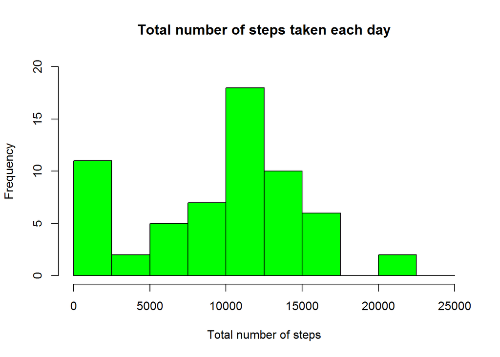

```r
totalData <- aggregate(activityNew$steps, by=list(activityNew$date), FUN=sum, na.rm=TRUE)

#rename heading
names(totalData) <- c("date", "total")

#plot histogram
hist(totalData$total,
     breaks=seq(from=0, to=25000, by=2500),
     col="green",
     xlab="Total number of steps",
     ylim=c(0, 20),
     main="Total number of steps taken each day")
```

###2. Calculate and report the mean and median total number of steps taken per day

```r
meanData<-mean(totalData$total)
medianData<-median(totalData$total)
```

#### The mean and median are 9354.23 and 10395, respectively

## What is the average daily activity pattern?

### 1. Make a time series plot (i.e. type = “l”) of the 5-minute interval (x-axis) and the average number of steps taken, averaged across all days (y-axis)

```r
#calculate the means of steps for all days for each interval
meanSteps <- aggregate(activityNew$steps, by=list(activityNew$interval),
                       FUN=mean, na.rm=TRUE)

#rename heading
names(meanSteps) <- c("interval", "mean")
```

#### structure of data

```r
str(meanSteps)
```

```
## 'data.frame':    288 obs. of  2 variables:
##  $ interval: int  0 5 10 15 20 25 30 35 40 45 ...
##  $ mean    : num  1.717 0.3396 0.1321 0.1509 0.0755 ...
```

### plot time series

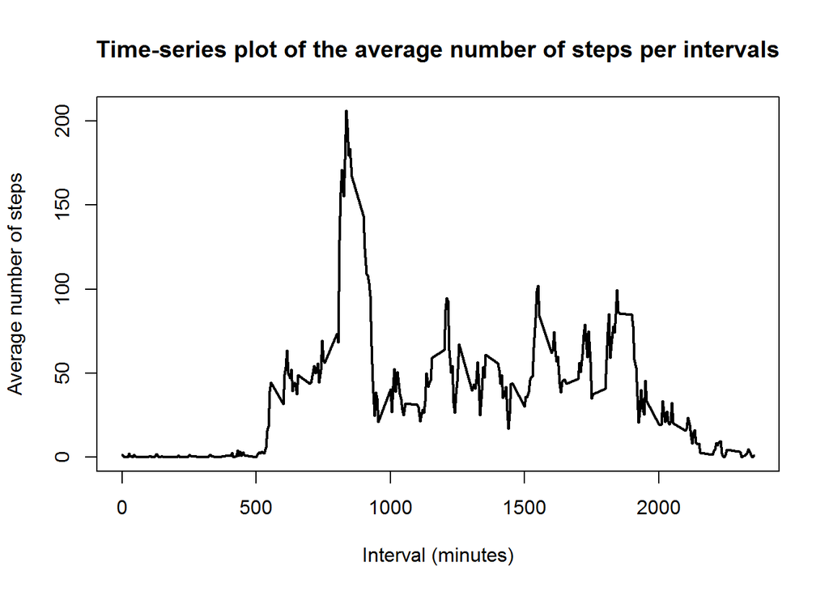

```r
#plot the time series
plot(meanSteps$interval,
     meanSteps$mean,
     type="l",
     col="black",
     lwd=2,
     xlab="Interval (minutes)",
     ylab="Average number of steps",
     main="Time-series plot of the average number of steps per intervals")
```

###2. Which 5-minute interval, on average across all the days in the dataset, contains the maximum number of steps?

```r
#locate maximum mean
max_pos_mean <- which(meanSteps$mean == max(meanSteps$mean))

#find the value
max_interval <- meanSteps[max_pos_mean, 1]
```

#### the average interval is 835

## Imputting the missing values

### 1. Calculate and report the total number of missing values in the dataset (i.e. the total number of rows with NA???s)

```r
#count number of NAs
NA.count <- sum(is.na(activityNew$steps))
```

#### data contains 2304 NAs

### 2. Devise a strategy for filling in all of the missing values in the dataset. The strategy does not need to be sophisticated. For example, you could use the mean/median for that day, or the mean for that 5-minute interval, etc.

```r
#locate NA positions
NA.pos <- which(is.na(activityNew$steps))

#create a vector
meanVector <- rep(mean(activityNew$steps, na.rm=TRUE), times=length(NA.pos))
```

### 3. Create a new dataset that is equal to the original dataset but with the missing data filled in.

```r
#replace NAs with the mean
activityNew[NA.pos, "steps"] <- meanVector
```

#### structure of data is

```r
str(activityNew)
```

```
## 'data.frame':    17568 obs. of  5 variables:
##  $ date    : POSIXct, format: "2012-10-01" "2012-10-01" ...
##  $ weekday : Factor w/ 7 levels "friday","monday",..: 2 2 2 2 2 2 2 2 2 2 ...
##  $ daytype : Factor w/ 2 levels "weekday","weekend": 1 1 1 1 1 1 1 1 1 1 ...
##  $ interval: int  0 5 10 15 20 25 30 35 40 45 ...
##  $ steps   : num  37.4 37.4 37.4 37.4 37.4 ...
```

### 4. Make a histogram of the total number of steps taken each day and calculate and report the mean and median total number of steps taken per day. Do these values differ from the estimates from the first part of the assignment? What is the impact of imputing missing data on the estimates of the total daily number of steps?

# calculate total number of steps

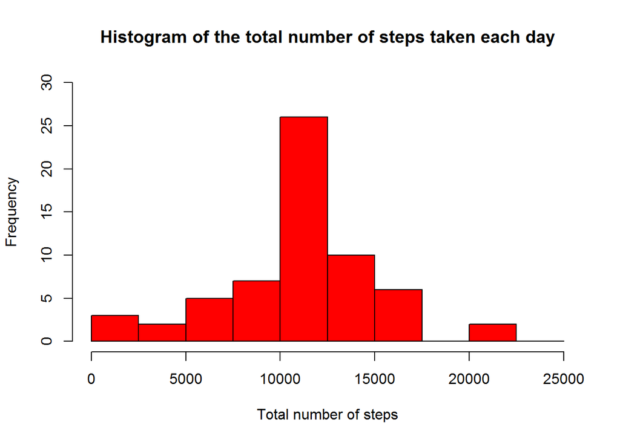

```r
totalData2 <- aggregate(activityNew$steps, by=list(activityNew$date), FUN=sum)

#rename heading
names(totalData2) <- c("date", "total")

#calculate the histogram of the total number of steps each day
hist(totalData2$total,
     breaks=seq(from=0, to=25000, by=2500),
     col="red",
     xlab="Total number of steps",
     ylim=c(0, 30),
     main="Histogram of the total number of steps taken each day")
```

####the code for calculating the mean and median

```r
meanData2<-mean(totalData2$total)
medianData2<-median(totalData2$total)
```

#### The mean and median are 10766.19 and 10766.18, respectively

#### these numbers differ from the previous estimate.

## Are there differences in activity patterns between weekdays and weekends?

### 1. Create a new factor variable in the dataset with two levels - ???weekdays??? and ???weekend??? indicating whether a given date is a weekday or weekend day.

```r
#already implemented is df
head(activityNew)
```

```
##         date weekday daytype interval   steps
## 1 2012-10-01  monday weekday        0 37.3826
## 2 2012-10-01  monday weekday        5 37.3826
## 3 2012-10-01  monday weekday       10 37.3826
## 4 2012-10-01  monday weekday       15 37.3826
## 5 2012-10-01  monday weekday       20 37.3826
## 6 2012-10-01  monday weekday       25 37.3826
```

### 2.Make a panel plot containing a time series plot (i.e. type = “l”) of the 5- minute interval (x-axis) and the average number of steps taken, averaged across all weekday days or weekend days (y-axis)

```r
# Load the lattice graphical library
library(lattice)

# Compute the average number of steps taken, averaged across all daytype variable
meanData3 <- aggregate(activityNew$steps, by=list(activityNew$daytype,
                               activityNew$weekday, activityNew$interval), mean)

#rename the heading
names(meanData3) <- c("daytype", "weekday", "interval", "mean")
```

# plot time series

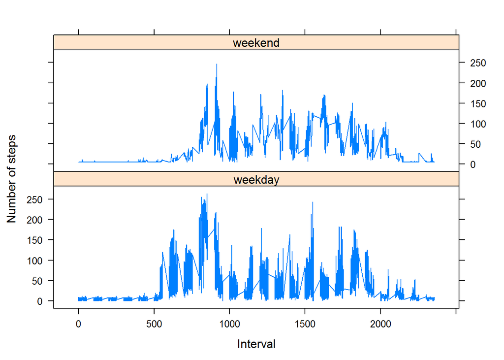

```r
xyplot(mean ~ interval | daytype, meanData3,
       type="l",
       lwd=1,
       xlab="Interval",
       ylab="Number of steps",
       layout=c(1,2))
```